# Analiza Danych Projekt

Jakub Zator, Mateusz Pałczyński, Jakub Pilarski

2025-01-14

# Wstęp

```r
agencja_nieruchomosci <- read.csv("agencja_nieruchomosci.csv")
knitr::kable(head(agencja_nieruchomosci, 10))
```

| price | area | bedrooms | bathrooms | stories | mainroad | guestroom | basement | hotwaterheating | airconditioning | parking | prefarea | furnishingstatus |
| --- | --- | --- | --- | --- | --- | --- | --- | --- | --- | --- | --- | --- |
| NA | 7420 | 4 | 2 | 3 | NA | no | no | no | yes | 2 | yes | furnished |
| 12250000 | 8960 | 4 | 4 | 4 | yes | no | no | no | yes | 3 | no | furnished |
| 12250000 | 9960 | 3 | 2 | 2 | yes | no | yes | no | no | 2 | yes | semi-furnished |
| 12215000 | 7500 | 4 | 2 | 2 | yes | no | yes | no | yes | 3 | yes | furnished |
| 11410000 | 7420 | 4 | 1 | 2 | yes | yes | yes | no | yes | 2 | no | furnished |
| 10850000 | 7500 | 3 | 3 | 1 | yes | no | yes | no | yes | 2 | yes | semi-furnished |
| 10150000 | 8580 | 4 | 3 | 4 | yes | no | no | no | yes | 2 | yes | semi-furnished |
| 10150000 | 16200 | 5 | 3 | 2 | yes | no | no | no | no | 0 | no | unfurnished |
| 9870000 | 8100 | 4 | 1 | 2 | yes | yes | yes | no | yes | 2 | yes | furnished |
| 9800000 | 5750 | 3 | 2 | 4 | yes | yes | no | no | yes | 1 | yes | unfurnished |

# czyszczenie danych

## Początkowa liczba i proporcje NA

Ogólne podsumowanie brakujących wartości

```r
knitr::kable(miss_var_summary(agencja_nieruchomosci))
```

| variable | n_miss | pct_miss |
| --- | --- | --- |
| price | 110 | 20.2 |
| mainroad | 50 | 9.17 |
| prefarea | 50 | 9.17 |
| area | 0 | 0 |
| bedrooms | 0 | 0 |
| bathrooms | 0 | 0 |
| stories | 0 | 0 |
| guestroom | 0 | 0 |
| basement | 0 | 0 |
| hotwaterheating | 0 | 0 |
| airconditioning | 0 | 0 |
| parking | 0 | 0 |
| furnishingstatus | 0 | 0 |

```r
library(validate)

rules <- validator(
  price > 0 & price < 100000000,
  area > 0 & area < 100000,
  bedrooms > -1 & bedrooms < 10,
  bathrooms > -1 & bathrooms < 10,
  stories > -1 & stories < 20,
  parking > -1 & parking < 5,
  mainroad %in% c("yes", "no"),
  guestroom %in% c("yes", "no"),
  basement %in% c("yes", "no"),
  hotwaterheating %in% c("yes", "no"),
  airconditioning %in% c("yes", "no"),
  prefarea %in% c("yes", "no"),
  furnishingstatus %in% c(
    "furnished",
    "semi-furnished",
    "unfurnished"
  )
)

warnings()

validation_results <- confront(agencja_nieruchomosci, rules)
knitr::kable(summary(validation_results))
```

| name | items | passes | fails | nNA | error | warning | expression |
| --- | --- | --- | --- | --- | --- | --- | --- |
| V01 | 545 | 435 | 0 | 110 | FALSE | FALSE | price > 0 & price < 1e+08 |
| V02 | 545 | 545 | 0 | 0 | FALSE | FALSE | area > 0 & area < 1e+05 |
| V03 | 545 | 545 | 0 | 0 | FALSE | FALSE | bedrooms > -1 & bedrooms < 10 |
| V04 | 545 | 545 | 0 | 0 | FALSE | FALSE | bathrooms > -1 & bathrooms < 10 |
| V05 | 545 | 545 | 0 | 0 | FALSE | FALSE | stories > -1 & stories < 20 |
| V06 | 545 | 545 | 0 | 0 | FALSE | FALSE | parking > -1 & parking < 5 |
| V07 | 545 | 495 | 0 | 50 | FALSE | FALSE | mainroad %vin% c(“yes”, “no”) |
| V08 | 545 | 545 | 0 | 0 | FALSE | FALSE | guestroom %vin% c(“yes”, “no”) |
| V09 | 545 | 545 | 0 | 0 | FALSE | FALSE | basement %vin% c(“yes”, “no”) |
| V10 | 545 | 545 | 0 | 0 | FALSE | FALSE | hotwaterheating %vin% c(“yes”, “no”) |
| V11 | 545 | 545 | 0 | 0 | FALSE | FALSE | airconditioning %vin% c(“yes”, “no”) |
| V12 | 545 | 495 | 0 | 50 | FALSE | FALSE | prefarea %vin% c(“yes”, “no”) |
| V13 | 545 | 545 | 0 | 0 | FALSE | FALSE | furnishingstatus %vin% c(“furnished”, “semi-furnished”, “unfurnished”) |

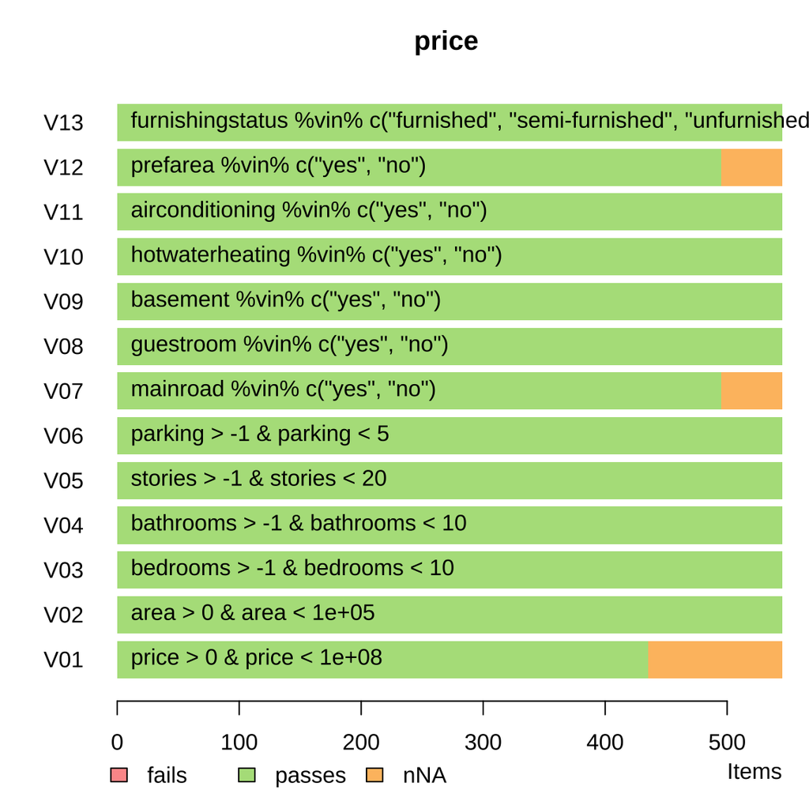

```r
barplot(validation_results, main = "price")
```

Funkcje summary i barplot zgodnie pokazują ze wszystkie nasze dane mają realne wartości.

Aby ułatwić dalszą pracę można zmienić wartości binarne yes i no na 0 i 1. Wartościom z kolumny furnished nadajemy kolejno wartości 0, 1 i 2 (od unfurnished do furnished).

```r
agencja_nieruchomosci$mainroad <-
  ifelse(agencja_nieruchomosci$mainroad == "yes", 1, 0)
agencja_nieruchomosci$guestroom <-
  ifelse(agencja_nieruchomosci$guestroom == "yes", 1, 0)
agencja_nieruchomosci$basement <-
  ifelse(agencja_nieruchomosci$basement == "yes", 1, 0)
agencja_nieruchomosci$hotwaterheating <-
  ifelse(agencja_nieruchomosci$hotwaterheating == "yes", 1, 0)
agencja_nieruchomosci$airconditioning <-
  ifelse(agencja_nieruchomosci$airconditioning == "yes", 1, 0)
agencja_nieruchomosci$prefarea <-
  ifelse(agencja_nieruchomosci$prefarea == "yes", 1, 0)

agencja_nieruchomosci$furnishingstatus <- ifelse(
  agencja_nieruchomosci$furnishingstatus == "unfurnished",
  0,
  ifelse(
    agencja_nieruchomosci$furnishingstatus == "semi-furnished",
    1,
    2
  )
)
knitr::kable(head(agencja_nieruchomosci, 10))
```

| price | area | bedrooms | bathrooms | stories | mainroad | guestroom | basement | hotwaterheating | airconditioning | parking | prefarea | furnishingstatus |
| --- | --- | --- | --- | --- | --- | --- | --- | --- | --- | --- | --- | --- |
| NA | 7420 | 4 | 2 | 3 | NA | 0 | 0 | 0 | 1 | 2 | 1 | 2 |
| 12250000 | 8960 | 4 | 4 | 4 | 1 | 0 | 0 | 0 | 1 | 3 | 0 | 2 |
| 12250000 | 9960 | 3 | 2 | 2 | 1 | 0 | 1 | 0 | 0 | 2 | 1 | 1 |
| 12215000 | 7500 | 4 | 2 | 2 | 1 | 0 | 1 | 0 | 1 | 3 | 1 | 2 |
| 11410000 | 7420 | 4 | 1 | 2 | 1 | 1 | 1 | 0 | 1 | 2 | 0 | 2 |
| 10850000 | 7500 | 3 | 3 | 1 | 1 | 0 | 1 | 0 | 1 | 2 | 1 | 1 |
| 10150000 | 8580 | 4 | 3 | 4 | 1 | 0 | 0 | 0 | 1 | 2 | 1 | 1 |
| 10150000 | 16200 | 5 | 3 | 2 | 1 | 0 | 0 | 0 | 0 | 0 | 0 | 0 |
| 9870000 | 8100 | 4 | 1 | 2 | 1 | 1 | 1 | 0 | 1 | 2 | 1 | 2 |
| 9800000 | 5750 | 3 | 2 | 4 | 1 | 1 | 0 | 0 | 1 | 1 | 1 | 0 |

Brakujące wartości wg. stanu umeblowania

```r
agencja_nieruchomosci %>%
  group_by(furnishingstatus) %>%
  miss_var_summary() %>%
  filter(n_miss > 0) %>%
  knitr::kable()
```

| furnishingstatus | variable | n_miss | pct_miss |
| --- | --- | --- | --- |
| 2 | price | 33 | 23.6 |
| 2 | prefarea | 15 | 10.7 |
| 2 | mainroad | 11 | 7.86 |
| 1 | price | 43 | 18.9 |
| 1 | mainroad | 23 | 10.1 |
| 1 | prefarea | 18 | 7.93 |
| 0 | price | 34 | 19.1 |
| 0 | prefarea | 17 | 9.55 |
| 0 | mainroad | 16 | 8.99 |

```r
agencja_nieruchomosci %>%
  miss_case_table() %>%
  knitr::kable()
```

| n_miss_in_case | n_cases | pct_cases |
| --- | --- | --- |
| 0 | 363 | 66.6055046 |
| 1 | 155 | 28.4403670 |
| 2 | 26 | 4.7706422 |
| 3 | 1 | 0.1834862 |

## Wizualizacja NA

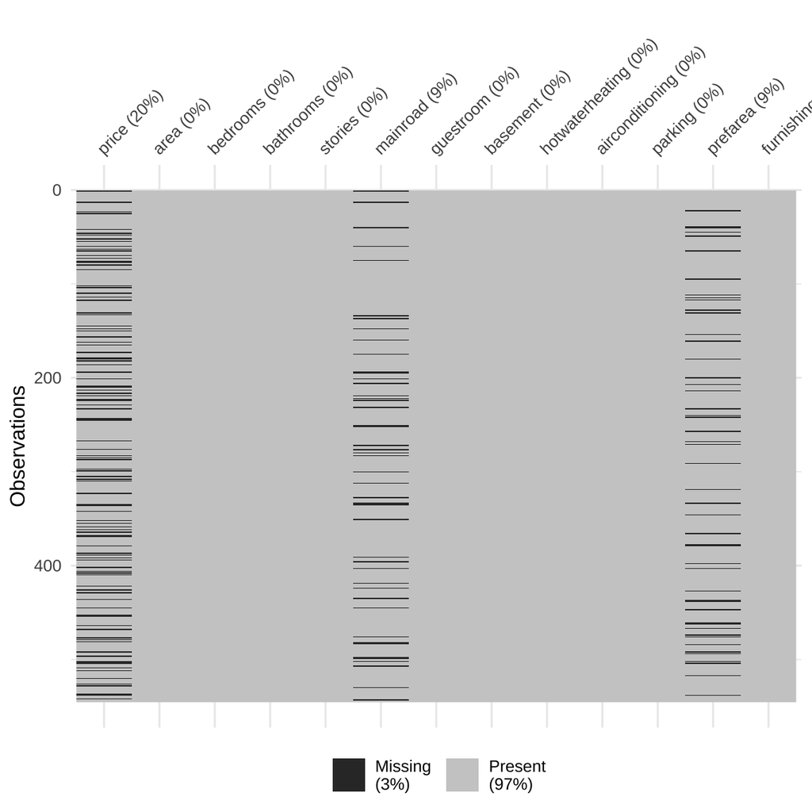

```r
vis_miss(agencja_nieruchomosci)
```

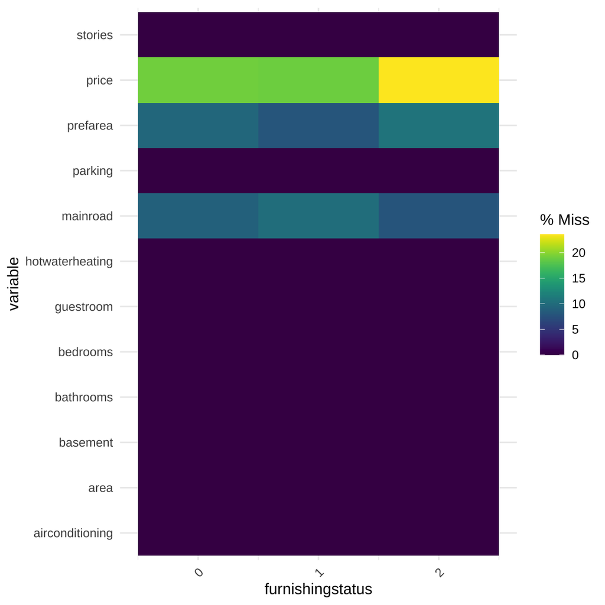

```r
gg_miss_fct(agencja_nieruchomosci, fct=furnishingstatus)
```

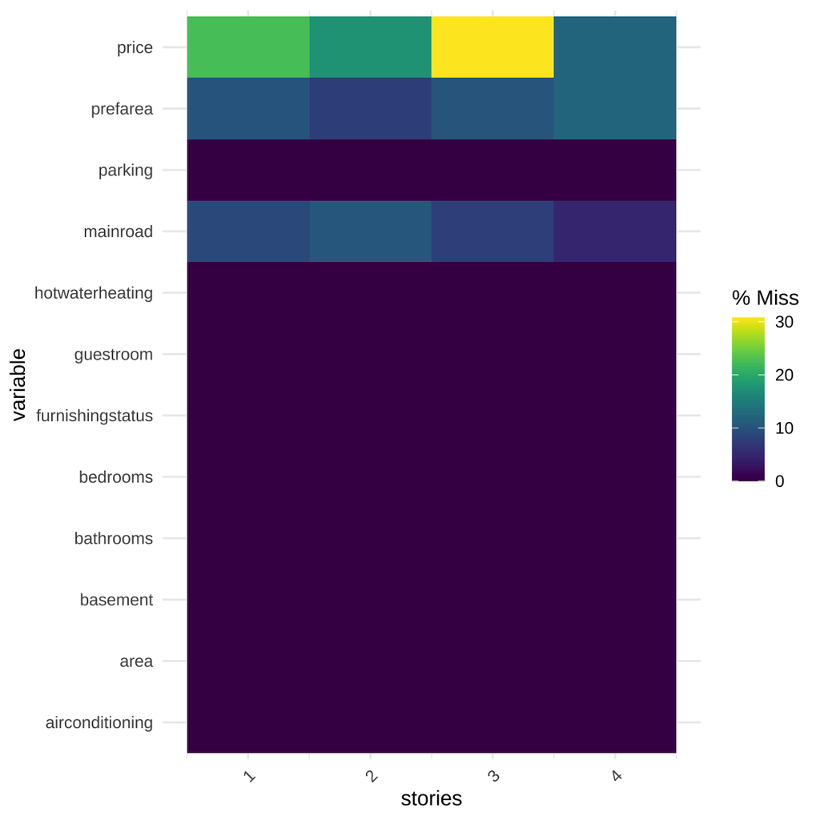

```r
gg_miss_fct(agencja_nieruchomosci, fct=stories)
```

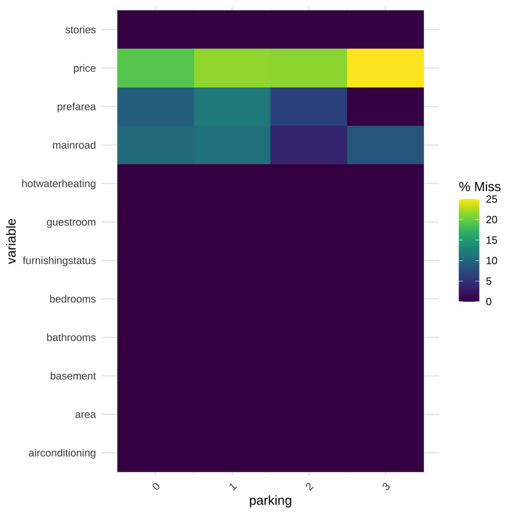

```r
gg_miss_fct(agencja_nieruchomosci, fct=parking)
```

Dzięki wykresom, które przedstawiają procent brakujących danych w zależności od filtru można wywnioskować, że największy procent brakujących danych jest zazwyczaj w momencie, gdzie jest najwieksza wartość dodatnia z konkretnych filtrów. Przykładowo największa ilość NA (price) jest w momencie, gdzie są 3 miejsca parkingowe.

## Przekroje NA

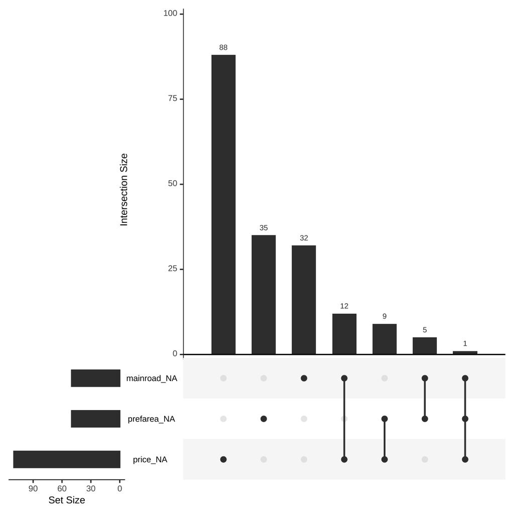

```r
gg_miss_upset(agencja_nieruchomosci, nsets=3)
```

Na powyższym wykresie widać, że najwięcej brakujących danych jest w kolumnie cena. Przyczyny są prawdopodobnie czysto praktycznie - za wysoka cena może odstraszyć potencjalnych klientów. Potencjalną przyczyną może oznaczać chęć zbierania ofert.

## Zależności pomiędzy brakującymi danymi.

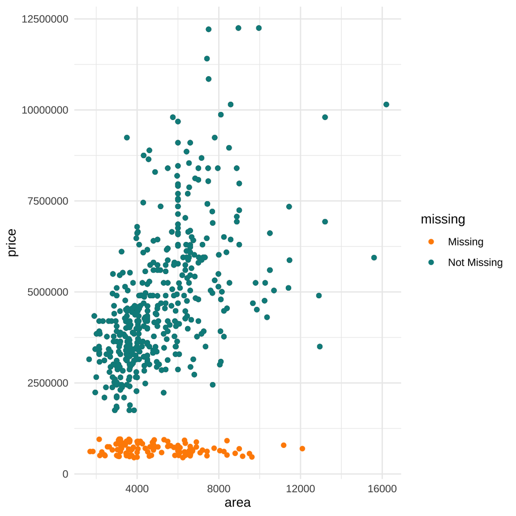

```r
ggplot(data = agencja_nieruchomosci, aes(x = area, y = price)) +
  geom_point() +
  geom_miss_point() +
  scale_color_manual(values = c("darkorange", "cyan4")) +
  theme_minimal()
```

W pierwszym przypadku widzimy, że brak wartości price był podobnie prawdopodobny do większości przypadków powierzchni domu. Można zauważyć brak NA w wielkości domu od 12 tys. do 16 tys. jednak są tam tylko pojedyncze wartości.

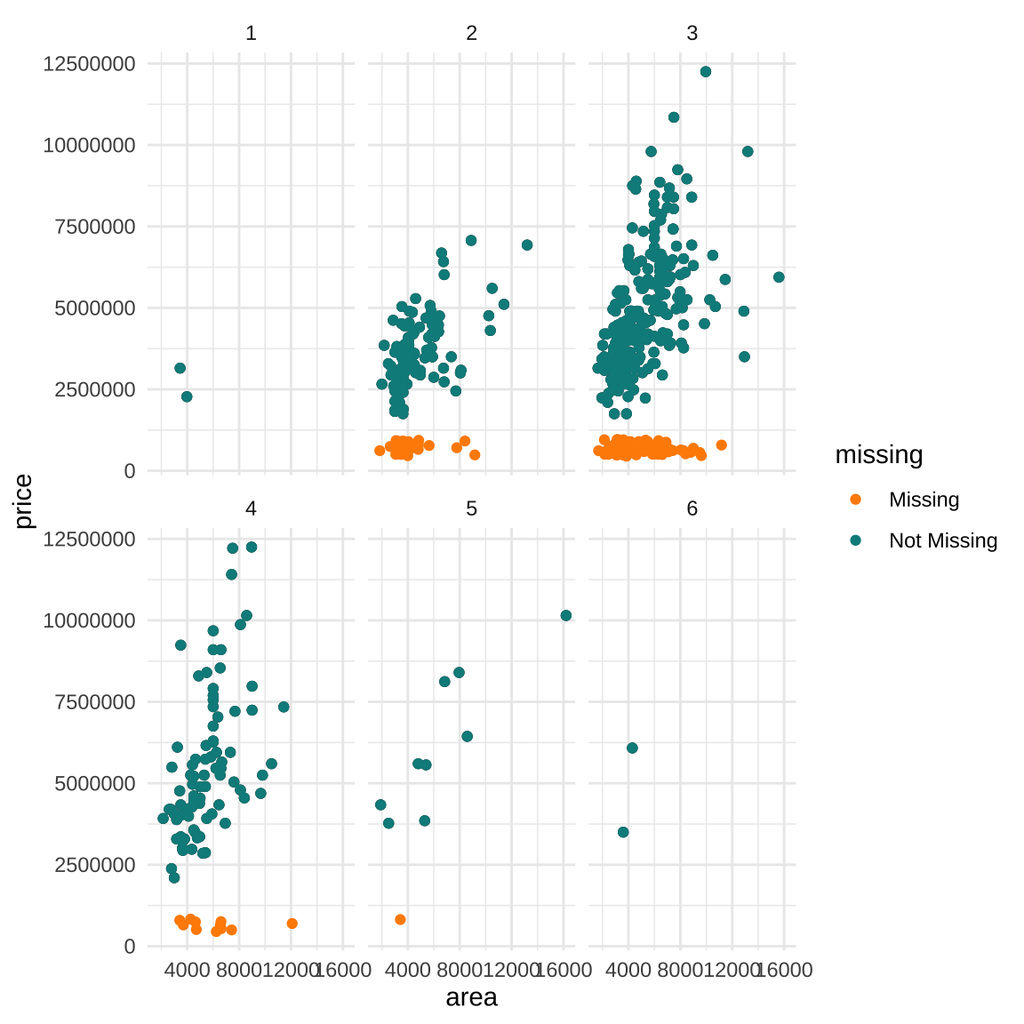

```r
ggplot(data = agencja_nieruchomosci, aes(x = area, y = price)) +
  geom_point() +
  geom_miss_point() +
  scale_color_manual(values = c("darkorange", "cyan4")) +
  theme_minimal() +
  facet_wrap(~bedrooms)
```

W podziale na podwykresy widzimy, że najwięcej NA znajduje sie w nieruchomościach, które mają 3 sypialnie.

# Data cleansing

## Imputacje danych

Identyfikacja brakujących danych jest kluczowym elementem czyszczenia datasetu. Kolejnym krokiem jest imputacja, czyli uzupełnienie brakujących komórek. Jest wiele metod umożliwiających imputację.

```r
agencja_nieruchomosci <- kNN(
  agencja_nieruchomosci,
  variable = "price",
  k = 15
)
agencja_nieruchomosci <- subset(agencja_nieruchomosci, select = -price_imp)
knitr::kable(miss_var_summary(agencja_nieruchomosci))
```

| variable | n_miss | pct_miss |
| --- | --- | --- |
| mainroad | 50 | 9.17 |
| prefarea | 50 | 9.17 |
| price | 0 | 0 |
| area | 0 | 0 |
| bedrooms | 0 | 0 |
| bathrooms | 0 | 0 |
| stories | 0 | 0 |
| guestroom | 0 | 0 |
| basement | 0 | 0 |
| hotwaterheating | 0 | 0 |
| airconditioning | 0 | 0 |
| parking | 0 | 0 |
| furnishingstatus | 0 | 0 |

Kolejną znaną metodą jest imputacja liniowa. Zmienne brakujące w kolumnie mainroad uzupełnione zostały wykorzystując metodę `impute_lm` pochodzącą z pakietu `simputation`. Wartości te imputujemy na podstawie zmiennych price oraz parking.

```r
agencja_nieruchomosci <- impute_lm(
  agencja_nieruchomosci,
  variable = "mainroad",
  formula = mainroad ~ price + parking,
)
agencja_nieruchomosci$mainroad <- round(agencja_nieruchomosci$mainroad)

knitr::kable(miss_var_summary(agencja_nieruchomosci))
```

| variable | n_miss | pct_miss |
| --- | --- | --- |
| prefarea | 50 | 9.17 |
| price | 0 | 0 |
| area | 0 | 0 |
| bedrooms | 0 | 0 |
| bathrooms | 0 | 0 |
| stories | 0 | 0 |
| mainroad | 0 | 0 |
| guestroom | 0 | 0 |
| basement | 0 | 0 |
| hotwaterheating | 0 | 0 |
| airconditioning | 0 | 0 |
| parking | 0 | 0 |
| furnishingstatus | 0 | 0 |

Dane w ostatniej brakującej kolumnie uzupeniamy metodą `mice` czyli Multivariate Imputation by Chained Equations - wielowymiarowe wypełnianie przez równania łańcuchowe. Jako że uzupeniamy zmienną binarną, korzystamy z metody logreg.

```r
imputed_data <- mice(agencja_nieruchomosci, method = "logreg", m = 5)
```

iter imp variable 1 1 prefarea 1 2 prefarea 1 3 prefarea 1 4 prefarea 1 5 prefarea 2 1 prefarea 2 2 prefarea 2 3 prefarea 2 4 prefarea 2 5 prefarea 3 1 prefarea 3 2 prefarea 3 3 prefarea 3 4 prefarea 3 5 prefarea 4 1 prefarea 4 2 prefarea 4 3 prefarea 4 4 prefarea 4 5 prefarea 5 1 prefarea 5 2 prefarea 5 3 prefarea 5 4 prefarea 5 5 prefarea

```r
completed_data <- complete(imputed_data, 1)
knitr::kable(completed_data %>% head(10))
```

| price | area | bedrooms | bathrooms | stories | mainroad | guestroom | basement | hotwaterheating | airconditioning | parking | prefarea | furnishingstatus |
| --- | --- | --- | --- | --- | --- | --- | --- | --- | --- | --- | --- | --- |
| 7910000 | 7420 | 4 | 2 | 3 | 1 | 0 | 0 | 0 | 1 | 2 | 1 | 2 |
| 12250000 | 8960 | 4 | 4 | 4 | 1 | 0 | 0 | 0 | 1 | 3 | 0 | 2 |
| 12250000 | 9960 | 3 | 2 | 2 | 1 | 0 | 1 | 0 | 0 | 2 | 1 | 1 |
| 12215000 | 7500 | 4 | 2 | 2 | 1 | 0 | 1 | 0 | 1 | 3 | 1 | 2 |
| 11410000 | 7420 | 4 | 1 | 2 | 1 | 1 | 1 | 0 | 1 | 2 | 0 | 2 |
| 10850000 | 7500 | 3 | 3 | 1 | 1 | 0 | 1 | 0 | 1 | 2 | 1 | 1 |
| 10150000 | 8580 | 4 | 3 | 4 | 1 | 0 | 0 | 0 | 1 | 2 | 1 | 1 |
| 10150000 | 16200 | 5 | 3 | 2 | 1 | 0 | 0 | 0 | 0 | 0 | 0 | 0 |
| 9870000 | 8100 | 4 | 1 | 2 | 1 | 1 | 1 | 0 | 1 | 2 | 1 | 2 |
| 9800000 | 5750 | 3 | 2 | 4 | 1 | 1 | 0 | 0 | 1 | 1 | 1 | 0 |

Zobaczmy jak wygląda pierwsze 10 wierszy naszego zbioru danych po imputacji:

```r
knitr::kable(head(agencja_nieruchomosci, 10))
```

| price | area | bedrooms | bathrooms | stories | mainroad | guestroom | basement | hotwaterheating | airconditioning | parking | prefarea | furnishingstatus |
| --- | --- | --- | --- | --- | --- | --- | --- | --- | --- | --- | --- | --- |
| 7910000 | 7420 | 4 | 2 | 3 | 1 | 0 | 0 | 0 | 1 | 2 | 1 | 2 |
| 12250000 | 8960 | 4 | 4 | 4 | 1 | 0 | 0 | 0 | 1 | 3 | 0 | 2 |
| 12250000 | 9960 | 3 | 2 | 2 | 1 | 0 | 1 | 0 | 0 | 2 | 1 | 1 |
| 12215000 | 7500 | 4 | 2 | 2 | 1 | 0 | 1 | 0 | 1 | 3 | 1 | 2 |
| 11410000 | 7420 | 4 | 1 | 2 | 1 | 1 | 1 | 0 | 1 | 2 | 0 | 2 |
| 10850000 | 7500 | 3 | 3 | 1 | 1 | 0 | 1 | 0 | 1 | 2 | 1 | 1 |
| 10150000 | 8580 | 4 | 3 | 4 | 1 | 0 | 0 | 0 | 1 | 2 | 1 | 1 |
| 10150000 | 16200 | 5 | 3 | 2 | 1 | 0 | 0 | 0 | 0 | 0 | 0 | 0 |
| 9870000 | 8100 | 4 | 1 | 2 | 1 | 1 | 1 | 0 | 1 | 2 | 1 | 2 |
| 9800000 | 5750 | 3 | 2 | 4 | 1 | 1 | 0 | 0 | 1 | 1 | 1 | 0 |

## Transformacje

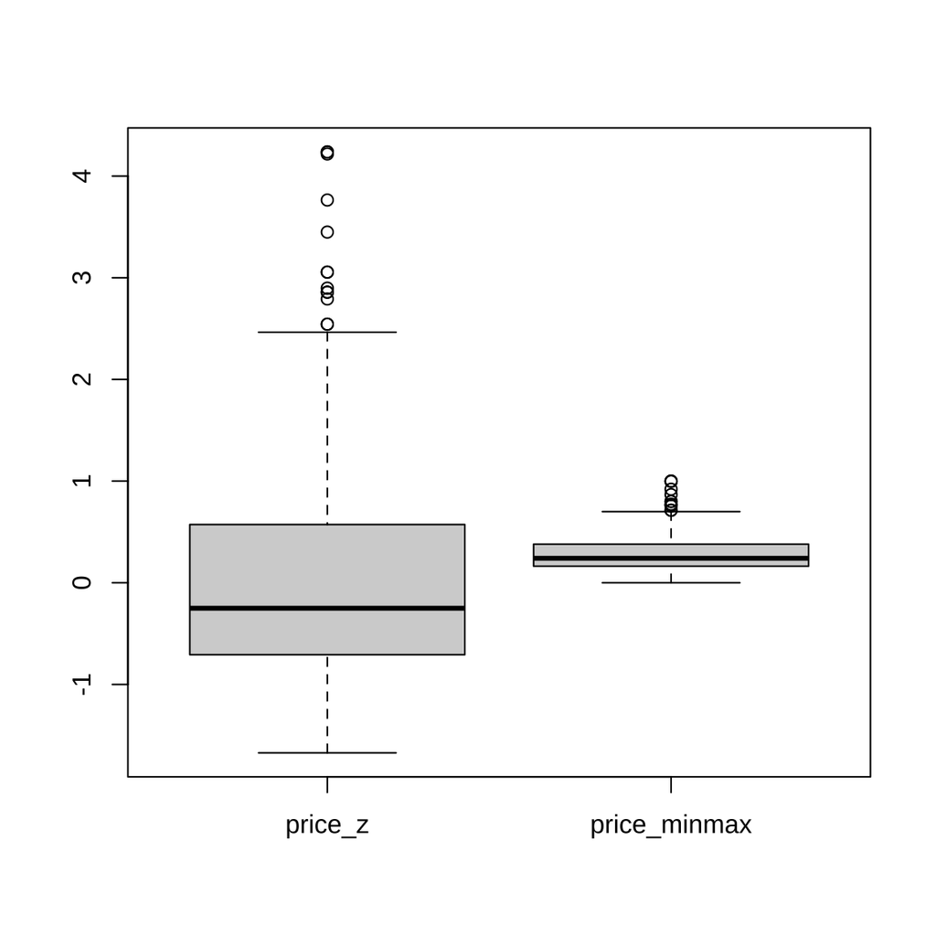

```r
agencja_nieruchomosci$price <- as.numeric(agencja_nieruchomosci$price)
agencja_nieruchomosci %>%
  mutate(
    price_z = transform(agencja_nieruchomosci$price, method ="zscore"),
    price_minmax = transform(agencja_nieruchomosci$price, method ="minmax")
  ) %>%
  select(price_z, price_minmax) %>%
  boxplot()
```

```r
find_skewness(agencja_nieruchomosci)
```

[1] 1 6 7 8 9 10 12

## Obserwacje odstające

```r
outlier_report <- diagnose_outlier(agencja_nieruchomosci)

knitr::kable(outlier_report)
```

| variables | outliers_cnt | outliers_ratio | outliers_mean | with_mean | without_mean |
| --- | --- | --- | --- | --- | --- |
| price | 13 | 2.3853211 | 1.053123e+07 | 4.721686e+06 | 4.579723e+06 |
| area | 12 | 2.2018349 | 1.269325e+04 | 5.150541e+03 | 4.980724e+03 |
| bedrooms | 12 | 2.2018349 | 5.166667e+00 | 2.965138e+00 | 2.915572e+00 |
| bathrooms | 1 | 0.1834862 | 4.000000e+00 | 1.286239e+00 | 1.281250e+00 |
| stories | 41 | 7.5229358 | 4.000000e+00 | 1.805505e+00 | 1.626984e+00 |
| mainroad | 67 | 12.2935780 | 0.000000e+00 | 8.770642e-01 | 1.000000e+00 |
| guestroom | 97 | 17.7981651 | 1.000000e+00 | 1.779817e-01 | 0.000000e+00 |
| basement | 0 | 0.0000000 | NaN | 3.504587e-01 | 3.504587e-01 |
| hotwaterheating | 25 | 4.5871560 | 1.000000e+00 | 4.587160e-02 | 0.000000e+00 |
| airconditioning | 0 | 0.0000000 | NaN | 3.155963e-01 | 3.155963e-01 |
| parking | 12 | 2.2018349 | 3.000000e+00 | 6.935780e-01 | 6.416510e-01 |
| prefarea | 122 | 22.3853211 | 1.000000e+00 | 2.464646e-01 | 0.000000e+00 |
| furnishingstatus | 0 | 0.0000000 | NaN | 9.302752e-01 | 9.302752e-01 |

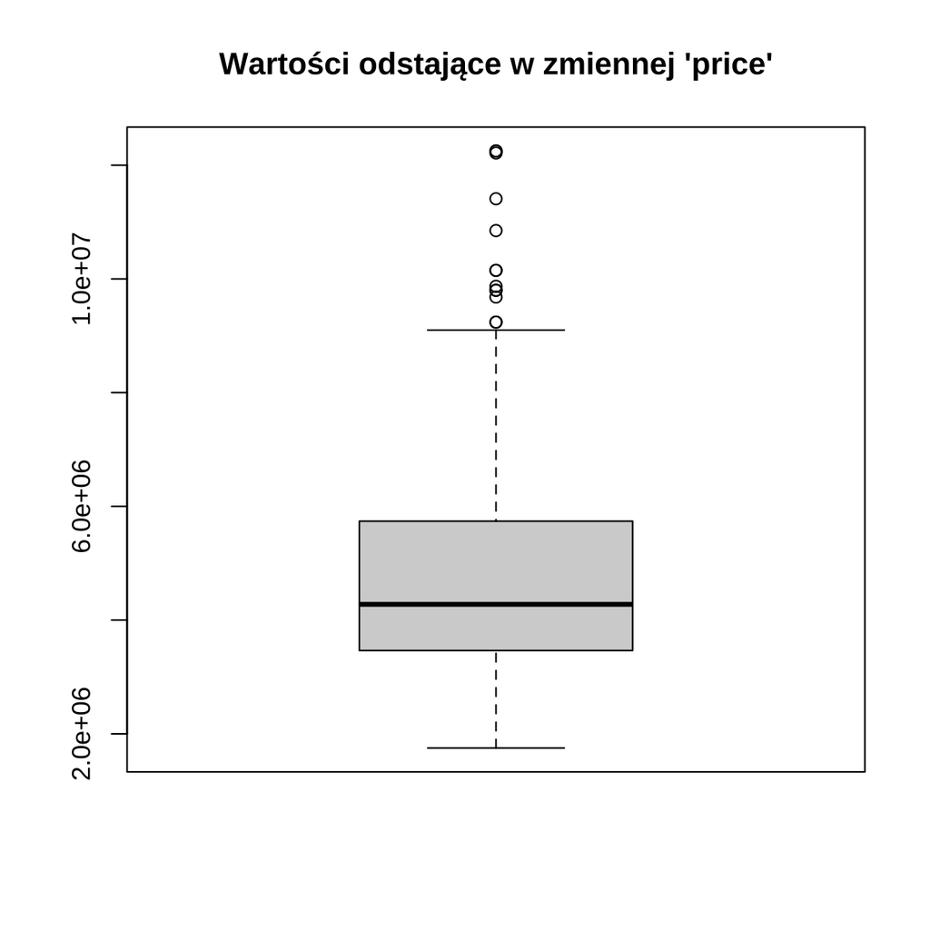

```r
boxplot(
  agencja_nieruchomosci$price,
  main = "Wartości odstające w zmiennej 'price'"
)
```